# Assignment 4

Jonathan Flores

February 2, 2018

## Question 1

FiveThirtyEight Data (30 points): Navigate on GitHub to https://github.com/rudeboybert/fivethirtyeight and read README.md. It includes everything you need.

1. Install the fivethirtyeight package.

```r
## install.packages("fivethirtyeight")
```

2. In the listing of Data sets in package ‘fivethirtyeight,’ assign the eighteenth data set to an object ‘df.’

```r
data(package = "fivethirtyeight")
```

Note: A large list of datasets shows, college_recent_grads is the 18th dataset. Not displaying the list as it is large

```r
df <- fivethirtyeight::college_recent_grads

## Displaying the first rows of the dataset to make sure it was assigned correctly

head(df)
```

rank major_code major major_category 1 1 2419 Petroleum Engineering Engineering 2 2 2416 Mining And Mineral Engineering Engineering 3 3 2415 Metallurgical Engineering Engineering 4 4 2417 Naval Architecture And Marine Engineering Engineering 5 5 2405 Chemical Engineering Engineering 6 6 2418 Nuclear Engineering Engineering total sample_size men women sharewomen employed employed_fulltime 1 2339 36 2057 282 0.1205643 1976 1849 2 756 7 679 77 0.1018519 640 556 3 856 3 725 131 0.1530374 648 558 4 1258 16 1123 135 0.1073132 758 1069 5 32260 289 21239 11021 0.3416305 25694 23170 6 2573 17 2200 373 0.1449670 1857 2038 employed_parttime employed_fulltime_yearround unemployed 1 270 1207 37 2 170 388 85 3 133 340 16 4 150 692 40 5 5180 16697 1672 6 264 1449 400 unemployment_rate p25th median p75th college_jobs non_college_jobs 1 0.01838053 95000 110000 125000 1534 364 2 0.11724138 55000 75000 90000 350 257 3 0.02409639 50000 73000 105000 456 176 4 0.05012531 43000 70000 80000 529 102 5 0.06109771 50000 65000 75000 18314 4440 6 0.17722641 50000 65000 102000 1142 657 low_wage_jobs 1 193 2 50 3 0 4 0 5 972 6 244

3. Use a more detailed list of the data sets to write out the URL in a comment to the related news story.

```r
## Vignette function details the dataset in much more detail. Assigning this to a variable, the variable can be used to be included in a related news story

URL <- vignette("fivethirtyeight", package = "fivethirtyeight")
```

4. Using R command(s), give the dimensions and column names of this data frame.

```r
## When using knitr and kableExtra libraries, we can format the tables according to specifications. Below showing the dataset with respective column names and dimensions for a table. Also, included a hover and scroll box to better fit the table on the screen

library(knitr)
library(kableExtra)
kable(df,"html") %>%
  kable_styling(bootstrap_options = c("striped", "hover"), full_width = F, font_size = 9) %>%
  scroll_box(width = "900px", height = "600px")
```

| rank | major_code | major | major_category | total | sample_size | men | women | sharewomen | employed | employed_fulltime | employed_parttime | employed_fulltime_yearround | unemployed | unemployment_rate | p25th | median | p75th | college_jobs | non_college_jobs | low_wage_jobs |
| --- | --- | --- | --- | --- | --- | --- | --- | --- | --- | --- | --- | --- | --- | --- | --- | --- | --- | --- | --- | --- |
| 1 | 2419 | Petroleum Engineering | Engineering | 2339 | 36 | 2057 | 282 | 0.1205643 | 1976 | 1849 | 270 | 1207 | 37 | 0.0183805 | 95000 | 110000 | 125000 | 1534 | 364 | 193 |
| 2 | 2416 | Mining And Mineral Engineering | Engineering | 756 | 7 | 679 | 77 | 0.1018519 | 640 | 556 | 170 | 388 | 85 | 0.1172414 | 55000 | 75000 | 90000 | 350 | 257 | 50 |
| 3 | 2415 | Metallurgical Engineering | Engineering | 856 | 3 | 725 | 131 | 0.1530374 | 648 | 558 | 133 | 340 | 16 | 0.0240964 | 50000 | 73000 | 105000 | 456 | 176 | 0 |
| 4 | 2417 | Naval Architecture And Marine Engineering | Engineering | 1258 | 16 | 1123 | 135 | 0.1073132 | 758 | 1069 | 150 | 692 | 40 | 0.0501253 | 43000 | 70000 | 80000 | 529 | 102 | 0 |
| 5 | 2405 | Chemical Engineering | Engineering | 32260 | 289 | 21239 | 11021 | 0.3416305 | 25694 | 23170 | 5180 | 16697 | 1672 | 0.0610977 | 50000 | 65000 | 75000 | 18314 | 4440 | 972 |
| 6 | 2418 | Nuclear Engineering | Engineering | 2573 | 17 | 2200 | 373 | 0.1449670 | 1857 | 2038 | 264 | 1449 | 400 | 0.1772264 | 50000 | 65000 | 102000 | 1142 | 657 | 244 |
| 7 | 6202 | Actuarial Science | Business | 3777 | 51 | 832 | 960 | 0.5357143 | 2912 | 2924 | 296 | 2482 | 308 | 0.0956522 | 53000 | 62000 | 72000 | 1768 | 314 | 259 |
| 8 | 5001 | Astronomy And Astrophysics | Physical Sciences | 1792 | 10 | 2110 | 1667 | 0.4413556 | 1526 | 1085 | 553 | 827 | 33 | 0.0211674 | 31500 | 62000 | 109000 | 972 | 500 | 220 |
| 9 | 2414 | Mechanical Engineering | Engineering | 91227 | 1029 | 12953 | 2105 | 0.1397928 | 76442 | 71298 | 13101 | 54639 | 4650 | 0.0573423 | 48000 | 60000 | 70000 | 52844 | 16384 | 3253 |
| 10 | 2408 | Electrical Engineering | Engineering | 81527 | 631 | 8407 | 6548 | 0.4378469 | 61928 | 55450 | 12695 | 41413 | 3895 | 0.0591738 | 45000 | 60000 | 72000 | 45829 | 10874 | 3170 |
| 11 | 2407 | Computer Engineering | Engineering | 41542 | 399 | 33258 | 8284 | 0.1994126 | 32506 | 30315 | 5146 | 23621 | 2275 | 0.0654093 | 45000 | 60000 | 75000 | 23694 | 5721 | 980 |
| 12 | 2401 | Aerospace Engineering | Engineering | 15058 | 147 | 65511 | 16016 | 0.1964503 | 11391 | 11106 | 2724 | 8790 | 794 | 0.0651621 | 42000 | 60000 | 70000 | 8184 | 2425 | 372 |
| 13 | 2404 | Biomedical Engineering | Engineering | 14955 | 79 | 80320 | 10907 | 0.1195589 | 10047 | 9017 | 2694 | 5986 | 1019 | 0.0920839 | 36000 | 60000 | 70000 | 6439 | 2471 | 789 |
| 14 | 5008 | Materials Science | Engineering | 4279 | 22 | 2949 | 1330 | 0.3108203 | 3307 | 2751 | 878 | 1967 | 78 | 0.0230428 | 39000 | 60000 | 65000 | 2626 | 391 | 81 |
| 15 | 2409 | Engineering Mechanics Physics And Science | Engineering | 4321 | 30 | 3526 | 795 | 0.1839852 | 3608 | 2999 | 811 | 2004 | 23 | 0.0063343 | 25000 | 58000 | 74000 | 2439 | 947 | 263 |
| 16 | 2402 | Biological Engineering | Engineering | 8925 | 55 | 6062 | 2863 | 0.3207843 | 6170 | 5455 | 1983 | 3413 | 589 | 0.0871431 | 40000 | 57100 | 76000 | 3603 | 1595 | 524 |
| 17 | 2412 | Industrial And Manufacturing Engineering | Engineering | 18968 | 183 | 12453 | 6515 | 0.3434732 | 15604 | 14879 | 2243 | 11326 | 699 | 0.0428755 | 37900 | 57000 | 67000 | 8306 | 3235 | 640 |
| 18 | 2400 | General Engineering | Engineering | 61152 | 425 | 45683 | 15469 | 0.2529598 | 44931 | 41235 | 7199 | 33540 | 2859 | 0.0598242 | 36000 | 56000 | 69000 | 26898 | 11734 | 3192 |
| 19 | 2403 | Architectural Engineering | Engineering | 2825 | 26 | 1835 | 990 | 0.3504425 | 2575 | 2277 | 343 | 1848 | 170 | 0.0619308 | 38000 | 54000 | 65000 | 1665 | 649 | 137 |
| 20 | 3201 | Court Reporting | Law & Public Policy | 1148 | 14 | 877 | 271 | 0.2360627 | 930 | 808 | 223 | 808 | 11 | 0.0116897 | 50000 | 54000 | 54000 | 402 | 528 | 144 |
| 21 | 2102 | Computer Science | Computers & Mathematics | 128319 | 1196 | 1837 | 2524 | 0.5787663 | 102087 | 91485 | 18726 | 70932 | 6884 | 0.0631728 | 39000 | 53000 | 70000 | 68622 | 25667 | 5144 |
| 22 | 1104 | Food Science | Agriculture & Natural Resources | 4361 | 36 | 99743 | 28576 | 0.2226950 | 3149 | 2558 | 1121 | 1735 | 338 | 0.0969315 | 32000 | 53000 | 70000 | 1183 | 1274 | 485 |
| 23 | 2502 | Electrical Engineering Technology | Engineering | 11565 | 97 | 2020 | 973 | 0.3250919 | 8587 | 7530 | 1873 | 5681 | 824 | 0.0875571 | 35000 | 52000 | 60000 | 5126 | 2686 | 696 |
| 24 | 2413 | Materials Engineering And Materials Science | Engineering | 2993 | 22 | 8181 | 3384 | 0.2926070 | 2449 | 1658 | 1040 | 1151 | 70 | 0.0277888 | 35000 | 52000 | 62000 | 1911 | 305 | 70 |
| 25 | 6212 | Management Information Systems And Statistics | Business | 18713 | 278 | 13496 | 5217 | 0.2787901 | 16413 | 15141 | 2420 | 13017 | 1015 | 0.0582396 | 38000 | 51000 | 60000 | 6342 | 5741 | 708 |
| 26 | 2406 | Civil Engineering | Engineering | 53153 | 565 | 41081 | 12072 | 0.2271179 | 43041 | 38302 | 10080 | 29196 | 3270 | 0.0706096 | 40000 | 50000 | 60000 | 28526 | 9356 | 2899 |
| 27 | 5601 | Construction Services | Industrial Arts & Consumer Services | 18498 | 295 | 2662 | 1385 | 0.3422288 | 16318 | 15690 | 1751 | 12313 | 1042 | 0.0600230 | 36000 | 50000 | 60000 | 3275 | 5351 | 703 |
| 28 | 6204 | Operations Logistics And E-Commerce | Business | 11732 | 156 | 488 | 232 | 0.3222222 | 10027 | 9639 | 1183 | 7724 | 504 | 0.0478587 | 40000 | 50000 | 60000 | 1466 | 3629 | 285 |
| 29 | 2499 | Miscellaneous Engineering | Engineering | 9133 | 118 | 7398 | 1735 | 0.1899704 | 7428 | 6811 | 1662 | 5476 | 597 | 0.0743925 | 39000 | 50000 | 65000 | 3445 | 2426 | 365 |
| 30 | 5402 | Public Policy | Law & Public Policy | 5978 | 55 | 2695 | 905 | 0.2513889 | 4547 | 4163 | 1306 | 2776 | 670 | 0.1284263 | 35000 | 50000 | 70000 | 1550 | 1871 | 340 |

[output cut: 143 more lines]

## 2. Data Summary (30 points):

Use your newly assigned data frame for Question 2.

1. Write an R command that gives you the column names of the data frame. Right after that, write one that counts the number of columns but not rows. Hint: The number should match one of your numbers in Question 1d for dimensions.

```r
colnames(df)
```

[1] “rank” “major_code”  
[3] “major” “major_category”  
[5] “total” “sample_size”  
[7] “men” “women”  
[9] “sharewomen” “employed”  
[11] “employed_fulltime” “employed_parttime”  
[13] “employed_fulltime_yearround” “unemployed”  
[15] “unemployment_rate” “p25th”  
[17] “median” “p75th”  
[19] “college_jobs” “non_college_jobs”  
[21] “low_wage_jobs”

```r
length(colnames(df))
```

[1] 21

2. Generate a count of each unique major_category in the data frame. I recommend using libraries to help. To be clear, this should look like a matrix or data frame containing the major_category and the frequency it occurs in the dataset. Assign it to major_count.

```r
library(plyr)
major_count <- count(df$major_category)
knitr::kable(major_count,"html")
```

| x | freq |
| --- | --- |
| Agriculture & Natural Resources | 10 |
| Arts | 8 |
| Biology & Life Science | 14 |
| Business | 13 |
| Communications & Journalism | 4 |
| Computers & Mathematics | 11 |
| Education | 16 |
| Engineering | 29 |
| Health | 12 |
| Humanities & Liberal Arts | 15 |
| Industrial Arts & Consumer Services | 7 |
| Interdisciplinary | 1 |
| Law & Public Policy | 5 |
| Physical Sciences | 10 |
| Psychology & Social Work | 9 |
| Social Science | 9 |

3. To make things easier to read, put par(las=2) before your plot to make the text perpendicular to the axis. Make a barplot of major_count. Make sure to label the title with something informative (check the vignette if you need), label the x and y axis, and make it any color other than grey. Assign the major_category labels to their respective bar. Flip the barplot horizontally so that bars extend to the right, not upward. All of these options can be done in a single pass of barplot(). Note: It’s okay if it’s wider than the preview pane

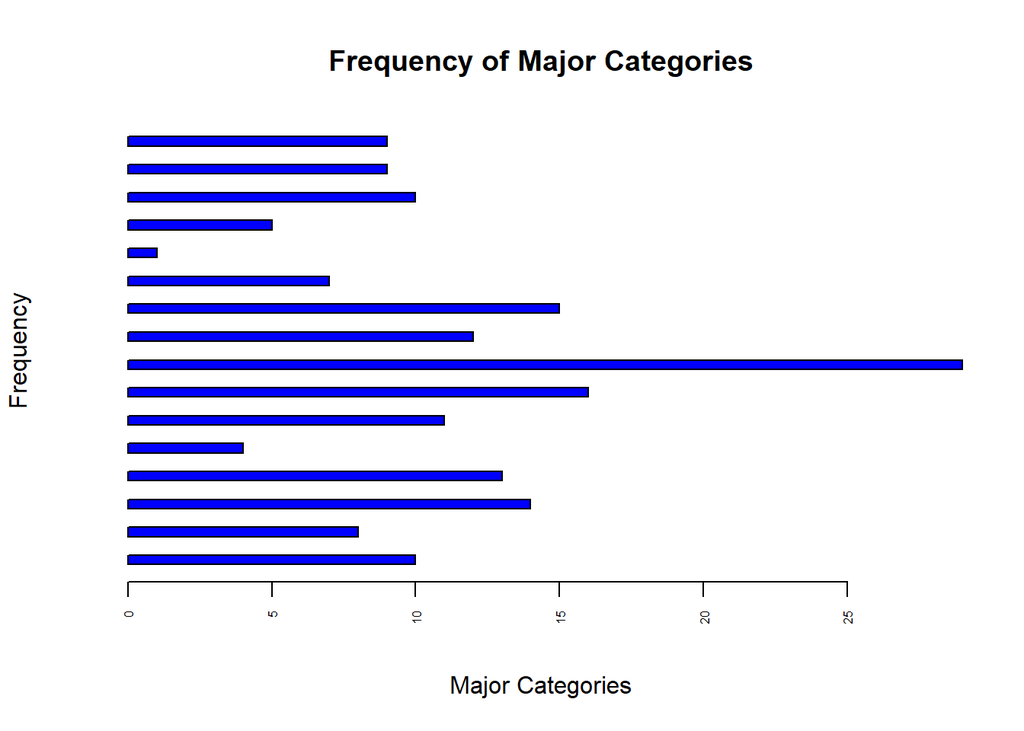

```r
par(las=2)
barplot(major_count$freq,axisnames = TRUE,space = 2,main = "Frequency of Major Categories", horiz = TRUE, font_size = 5,xlab="Major Categories",ylab="Frequency",cex.names = .5, cex.axis = .5,col = "blue")
```

4. Write the fivethirtyeight data to a csv file. Make sure that it does not have row labels.

```r
setwd("C:/Users/jfzjonathan/Desktop/Doing Data Science/Unit 4")
write.csv(major_count,file="Major_Count.csv",row.names = FALSE)
```

## 3. Codebook

1. Start a new repository on GitHub for your SMU MSDS homework. On your local device, make sure there is a directory for Homework at the minimum; you are welcome to add whatever you would like to this repo in addition to your requirements here.

```r
## Repo was created in github, named "Homework4" as well as in local computer
```

2. Create a README.md file which explains the purpose of the repository, the topics included, the sources for the material you post, and contact information in case of questions. Remember, the one in the root directory should be general. You are welcome to make short READMEs for each assignment individually in other folders.

```r
## README file has been created in the repo
```

c.In one (or more) of the nested directories, post your RMarkdown script, HTML file, and data from ‘fivethirtyeight.’ Make sure that in your README or elsewhere that you credit fivethirtyeight in some way.

C:Data Science44>git add .

C:Data Science44>git commit -a -m “Initial Commit” On branch master nothing to commit, working tree clean

C:Data Science44>git push origin master To https://github.com/jfzjonathan/Homework4.git ! [rejected] master -> master (fetch first) error: failed to push some refs to ‘https://github.com/jfzjonathan/Homework4.git’ hint: Updates were rejected because the remote contains work that you do hint: not have locally. This is usually caused by another repository pushing hint: to the same ref. You may want to first integrate the remote changes hint: (e.g., ‘git pull …’) before pushing again. hint: See the ‘Note about fast-forwards’ in ‘git push –help’ for details.

C:Data Science44>git push –force origin master Counting objects: 9, done. Delta compression using up to 4 threads. Compressing objects: 100% (7/7), done. Writing objects: 100% (9/9), 270.87 KiB | 6.30 MiB/s, done. Total 9 (delta 0), reused 0 (delta 0) To https://github.com/jfzjonathan/Homework4.git + e659b68…36bfb85 master -> master (forced update)

C:Data Science44>

```r
##
```

4. In your RMarkdown script, please provide the link to this GitHub so the grader can see it.